# Coursera Machine Learning Project

Gaurav A Singh

February 11, 2017

## Introduction

This is writeup for the final project for Coursera Machine Learning. The data we’ll use contains readings for barbell lifts captured by accelerometers. You can read more about the data here: http://groupware.les.inf.puc-rio.br/har We will create a model to predict the manner in which the participants performed the exercise. We will also use 20 different test cases.

## The Data

Let’s import the data and see what features they have.

```r
pmlTraining <- read.csv('pml-training.csv')
pmlTesting <- read.csv('pml-testing.csv')
```

```
## [1] 19622   160
```

```
##   [1] "X"                        "user_name"
##   [3] "raw_timestamp_part_1"     "raw_timestamp_part_2"
##   [5] "cvtd_timestamp"           "new_window"
##   [7] "num_window"               "roll_belt"
##   [9] "pitch_belt"               "yaw_belt"
##  [11] "total_accel_belt"         "kurtosis_roll_belt"
##  [13] "kurtosis_picth_belt"      "kurtosis_yaw_belt"
##  [15] "skewness_roll_belt"       "skewness_roll_belt.1"
##  [17] "skewness_yaw_belt"        "max_roll_belt"
##  [19] "max_picth_belt"           "max_yaw_belt"
##  [21] "min_roll_belt"            "min_pitch_belt"
##  [23] "min_yaw_belt"             "amplitude_roll_belt"
##  [25] "amplitude_pitch_belt"     "amplitude_yaw_belt"
##  [27] "var_total_accel_belt"     "avg_roll_belt"
##  [29] "stddev_roll_belt"         "var_roll_belt"
```

[output cut: 65 more lines]

Both the training and testing data sets contain 160 columns. The most important one is **classe** as our model will be predicting this. Let’s look at a set of values for this.

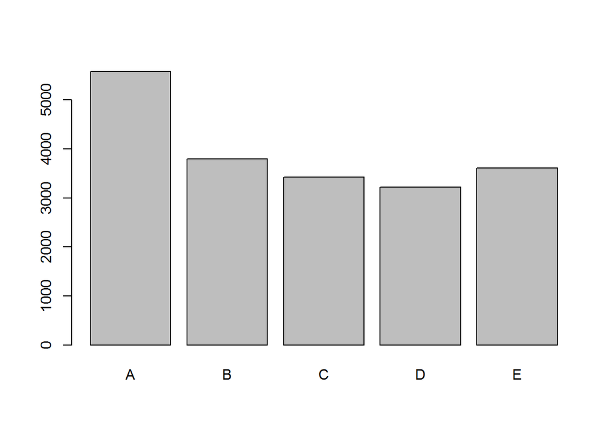

As depicted above, there are 5 different classification levels, thus, we should use classification models for this exercise.

### Preprocessing

Looking at the data, we notice 2 things:  
1. First 7 columns are record identifiers  
2. There are numerous empty values, NAs and #DIV/0s

```
##   X user_name raw_timestamp_part_1 raw_timestamp_part_2   cvtd_timestamp
## 1 1  carlitos           1323084231               788290 05/12/2011 11:23
## 2 2  carlitos           1323084231               808298 05/12/2011 11:23
## 3 3  carlitos           1323084231               820366 05/12/2011 11:23
## 4 4  carlitos           1323084232               120339 05/12/2011 11:23
## 5 5  carlitos           1323084232               196328 05/12/2011 11:23
## 6 6  carlitos           1323084232               304277 05/12/2011 11:23
##   new_window num_window roll_belt pitch_belt yaw_belt total_accel_belt
## 1         no         11      1.41       8.07    -94.4                3
## 2         no         11      1.41       8.07    -94.4                3
## 3         no         11      1.42       8.07    -94.4                3
## 4         no         12      1.48       8.05    -94.4                3
## 5         no         12      1.48       8.07    -94.4                3
## 6         no         12      1.45       8.06    -94.4                3
##   kurtosis_roll_belt kurtosis_picth_belt kurtosis_yaw_belt
```

[output cut: 265 more lines]

We will now use the pmlTraining data frame and remove the first 7 columns and make all the other columns numeric. We’ll also do the same thing for the pmlTesting data frame. Subsequently, we’ll remove columns that do not have any values - we will use the testing dataset to find columns that are empty and are not needed.

```r
pmlTraining.pre <- pmlTraining[,8:160]
pmlTraining.pre [,1:152] <- sapply(pmlTraining.pre[,1:152], as.numeric)
pmlTesting.pre <- pmlTesting[,8:160]
pmlTesting.pre [,1:152] <- sapply(pmlTesting.pre[,1:152], as.numeric)

emptyCols.Test <- colSums(is.na(pmlTesting.pre))!=0
pmlTesting.pre <- pmlTesting.pre[,!emptyCols.Test]
pmlTraining.pre <- pmlTraining.pre[,!emptyCols.Test]
```

Next, we will split the training data frame into traing and testing datasets for our model. The pmlTesting.pre dataset will be used to answer the problems in the project quiz.

```r
trainInd <- createDataPartition(pmlTraining.pre$classe, p=0.7, list =F)
trainPml <- pmlTraining.pre[trainInd,]
testPml <- pmlTraining.pre[-trainInd,]
```

```
##    Dataset Observations Variables
## 1 Training        13737        53
## 2  Testing         5885        53
```

## The Model

### rpart

Let’s begin with an **rpart** model.

```r
rpartFit <- train(classe~., method='rpart',data=trainPml)
pred.rpart <- predict(rpartFit, testPml)
cm.rpart <- confusionMatrix(testPml$classe, pred.rpart)
```

```r
cm.rpart$overall
```

```
##       Accuracy          Kappa  AccuracyLower  AccuracyUpper   AccuracyNull
##      0.4971963      0.3427390      0.4843410      0.5100543      0.5204758
## AccuracyPValue  McnemarPValue
##      0.9998323            NaN
```

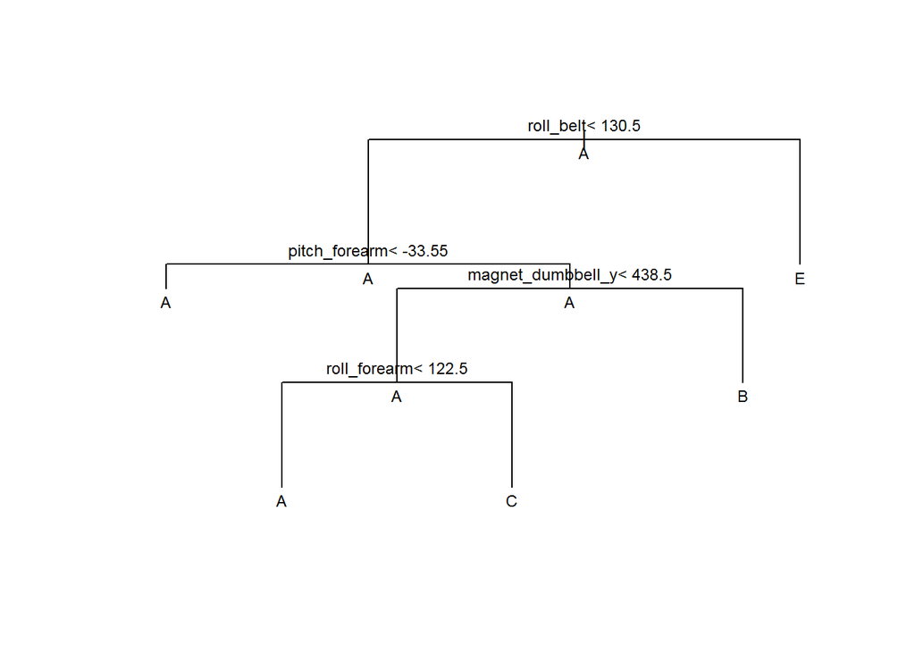

```r
plot(rpartFit$finalModel, branch=1, margin=.05, compress=T, uniform=F)
text(rpartFit$finalModel, all = T, cex=0.75, pretty=T)
```

### rf

Let’s now use an **rf** model. We also use 3-fold **cross validation** here. We use 3 instead of 10 due to lesser computational power required for 3-fold.

```r
fitControl <- trainControl(method = 'cv', number=3)
rfFit <- train(classe~., method='rf',data=trainPml, trControl=fitControl)
pred.rf <- predict(rfFit, testPml)
cm.rf <- confusionMatrix(testPml$classe, pred.rf)
```

```r
cm.rf$overall
```

```
##       Accuracy          Kappa  AccuracyLower  AccuracyUpper   AccuracyNull
##      0.9933730      0.9916155      0.9909517      0.9952834      0.2863212
## AccuracyPValue  McnemarPValue
##      0.0000000            NaN
```

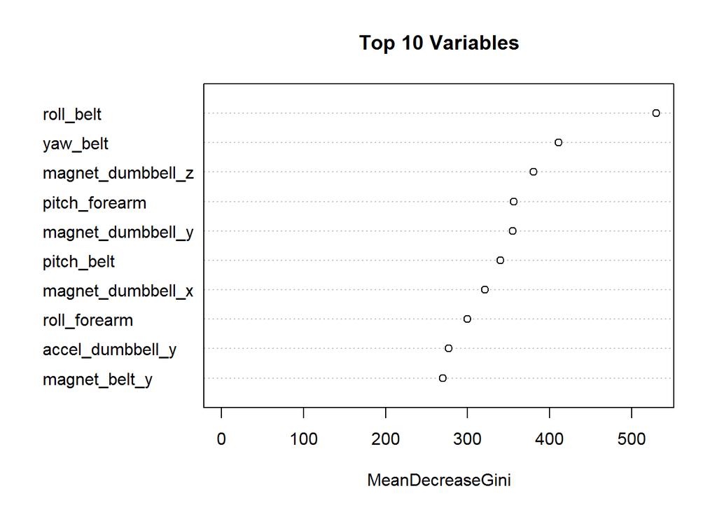

```r
varImpPlot(rfFit$finalModel, n.var=10, main="Top 10 Variables")
```

Woah! Seems like we have a winner here. With 99.3% accuracy, this will probably be the best model we can come up with. But, let’s try one more since good things come in 3s.

### treebag

Let’s now use the **bagging** model.

```r
bagFit <- train(classe~., method='treebag',data=trainPml)
pred.bag <- predict(bagFit, testPml)
cm.bag <- confusionMatrix(testPml$classe, pred.bag)
```

```r
cm.bag$overall
```

```
##       Accuracy          Kappa  AccuracyLower  AccuracyUpper   AccuracyNull
##      0.9882753      0.9851681      0.9851848      0.9908663      0.2849618
## AccuracyPValue  McnemarPValue
##      0.0000000            NaN
```

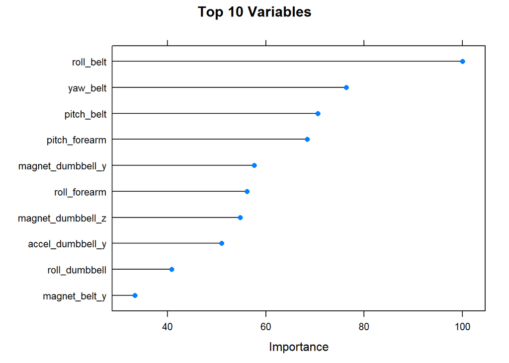

```r
plot(varImp(bagFit), top=10, main='Top 10 Variables')
```

This model’s pretty good as well - 98.8% accuracy.

## Model Selection and Prediction Results

Let’s compare all the models and pick the **rf** model.

```
##              rpart       rf   treebag
## Accuracy 0.4971963 0.993373 0.9882753
```

```
## Confusion Matrix and Statistics
##
##           Reference
## Prediction    A    B    C    D    E
##          A 1674    0    0    0    0
##          B   11 1126    2    0    0
##          C    0    5 1020    1    0
##          D    0    0   19  945    0
##          E    0    0    0    1 1081
##
## Overall Statistics
##
##                Accuracy : 0.9934
##                  95% CI : (0.991, 0.9953)
##     No Information Rate : 0.2863
##     P-Value [Acc > NIR] : < 2.2e-16
##
##                   Kappa : 0.9916
##  Mcnemar's Test P-Value : NA
##
## Statistics by Class:
##
##                      Class: A Class: B Class: C Class: D Class: E
## Sensitivity            0.9935   0.9956   0.9798   0.9979   1.0000
## Specificity            1.0000   0.9973   0.9988   0.9962   0.9998
## Pos Pred Value         1.0000   0.9886   0.9942   0.9803   0.9991
## Neg Pred Value         0.9974   0.9989   0.9957   0.9996   1.0000
## Prevalence             0.2863   0.1922   0.1769   0.1609   0.1837
## Detection Rate         0.2845   0.1913   0.1733   0.1606   0.1837
## Detection Prevalence   0.2845   0.1935   0.1743   0.1638   0.1839
## Balanced Accuracy      0.9967   0.9964   0.9893   0.9970   0.9999
```

Let’s predict the 20 test cases to answer the quiz.

```r
pred.test <- predict(rfFit, pmlTesting.pre)
```

The results:

```
##    Prediction
## 1           B
## 2           A
## 3           B
## 4           A
## 5           A
## 6           E
## 7           D
## 8           B
## 9           A
## 10          A
## 11          B
## 12          C
## 13          B
## 14          A
## 15          E
## 16          E
## 17          A
## 18          B
## 19          B
## 20          B
```